# Case Study: How a Wellness Technology Company Play it Smart

SANDRA BOAKYE

2024-05-15

# First Phase: Ask

## Introduction and Background

# This case study is about Bellabeat, a high-tech manufacturer of health-focused products for women. Bellabeat is a successful small company which have the potential to become a larger player in the global smart device market. Urška Sršen and Sando Mur founded Bellabeat and there is also the Bellabeat marketing analytics team. Products of Bellabeat includes:

- Bellabeat app: The Bellabeat app provides users with health data related to their activity, sleep, stress, menstrual cycle, and mindfulness habits.
- Leaf: Bellabeat’s classic wellness tracker can be worn as a bracelet, necklace, or clip. The Leaf tracker connects to the Bellabeat app to track activity, sleep, and stress.
- Time: This wellness watch combines the timeless look of a classic timepiece with smart technology to track user activity, sleep, and stress. The Time watch connects to the Bellabeat app to provide insights into your daily wellness.
- Spring: This is a water bottle that tracks daily water intake using smart technology to ensure that users are appropriately hydrated throughout the day. The Spring bottle connects to the Bellabeat app to track hydration levels.
- Bellabeat membership: Bellabeat also offers a subscription-based membership program for users. Membership gives users 24/7 access to fully personalized guidance on nutrition, activity, sleep, health, beauty, and mindfulness based on their lifestyle and goals.

## Business Task

To analyze smart device usage data to gain insight into how consumers use non-Bellabeat smart devices and then select one Bellabeat product to apply these insights to. * Analyze Fitbit fitness tracker data to gain insights into how consumers are using the app and discover trends for Bellabeat marketing strategy.

## Key Stakeholders

- Urška Sršen and Sando Mur

# Second Phase: Prepare

## Data Source

# The data is not credible, it’s bad data.

## Data Selection

- Daily activities
- Sleep day

## Tool

• R for data cleaning, transformation, and visualization

# Third Phase: Process

- Install and load packages
- Import data
- View data
- Clean data
- Transform data
- Visualize data
- Documentation

# Fourth Phase: Analyze

# csv files uploaded by using the upload functionat the lower right of the environmental pane.

```r
install.packages("here")
install.packages("tidyverse")
install.packages("skimr")
install.packages("janitor")
install.packages("dplyr")
library(here)
library(tidyverse)
library(skimr)
library(janitor)
library(dplyr)
```

## Load and csv files

```r
library(readr)
daily_activity <- read_csv("mturkfitbit_export_4.12.16-5.12.16/Fitabase Data 4.12.16-5.12.16/dailyActivity_merged.csv")
 sleep_day <- read_csv("mturkfitbit_export_4.12.16-5.12.16/Fitabase Data 4.12.16-5.12.16/sleepDay_merged.csv")
 weight_Log_Info <- read_csv("mturkfitbit_export_4.12.16-5.12.16/Fitabase Data 4.12.16-5.12.16/weightLogInfo_merged.csv")
```

## Getting to know your data

```r
head(daily_activity)
```

```
## # A tibble: 6 × 15
##           Id ActivityDate TotalSteps TotalDistance TrackerDistance
##        <dbl> <chr>             <dbl>         <dbl>           <dbl>
## 1 1503960366 4/12/2016         13162          8.5             8.5
## 2 1503960366 4/13/2016         10735          6.97            6.97
## 3 1503960366 4/14/2016         10460          6.74            6.74
## 4 1503960366 4/15/2016          9762          6.28            6.28
## 5 1503960366 4/16/2016         12669          8.16            8.16
## 6 1503960366 4/17/2016          9705          6.48            6.48
## # ℹ 10 more variables: LoggedActivitiesDistance <dbl>,
## #   VeryActiveDistance <dbl>, ModeratelyActiveDistance <dbl>,
## #   LightActiveDistance <dbl>, SedentaryActiveDistance <dbl>,
## #   VeryActiveMinutes <dbl>, FairlyActiveMinutes <dbl>,
## #   LightlyActiveMinutes <dbl>, SedentaryMinutes <dbl>, Calories <dbl>
```

```r
 head(sleep_day)
```

```
## # A tibble: 6 × 5
##           Id SleepDay        TotalSleepRecords TotalMinutesAsleep TotalTimeInBed
##        <dbl> <chr>                       <dbl>              <dbl>          <dbl>
## 1 1503960366 4/12/2016 12:0…                 1                327            346
## 2 1503960366 4/13/2016 12:0…                 2                384            407
## 3 1503960366 4/15/2016 12:0…                 1                412            442
## 4 1503960366 4/16/2016 12:0…                 2                340            367
## 5 1503960366 4/17/2016 12:0…                 1                700            712
## 6 1503960366 4/19/2016 12:0…                 1                304            320
```

```r
 head(weight_Log_Info)
```

```
## # A tibble: 6 × 8
##           Id Date       WeightKg WeightPounds   Fat   BMI IsManualReport   LogId
##        <dbl> <chr>         <dbl>        <dbl> <dbl> <dbl> <lgl>            <dbl>
## 1 1503960366 5/2/2016 …     52.6         116.    22  22.6 TRUE           1.46e12
## 2 1503960366 5/3/2016 …     52.6         116.    NA  22.6 TRUE           1.46e12
## 3 1927972279 4/13/2016…    134.          294.    NA  47.5 FALSE          1.46e12
## 4 2873212765 4/21/2016…     56.7         125.    NA  21.5 TRUE           1.46e12
## 5 2873212765 5/12/2016…     57.3         126.    NA  21.7 TRUE           1.46e12
## 6 4319703577 4/17/2016…     72.4         160.    25  27.5 TRUE           1.46e12
```

## Identify all the columns in the three data.

```r
colnames(daily_activity)
```

```
##  [1] "Id"                       "ActivityDate"
##  [3] "TotalSteps"               "TotalDistance"
##  [5] "TrackerDistance"          "LoggedActivitiesDistance"
##  [7] "VeryActiveDistance"       "ModeratelyActiveDistance"
##  [9] "LightActiveDistance"      "SedentaryActiveDistance"
## [11] "VeryActiveMinutes"        "FairlyActiveMinutes"
## [13] "LightlyActiveMinutes"     "SedentaryMinutes"
## [15] "Calories"
```

```r
colnames(sleep_day)
```

```
## [1] "Id"                 "SleepDay"           "TotalSleepRecords"
## [4] "TotalMinutesAsleep" "TotalTimeInBed"
```

```r
colnames(weight_Log_Info)
```

```
## [1] "Id"             "Date"           "WeightKg"       "WeightPounds"
## [5] "Fat"            "BMI"            "IsManualReport" "LogId"
```

# All the datasets have one thing in common and that’s the field named “id”.

## Summary Satistics

```r
n_distinct(daily_activity$Id)
```

```
## [1] 33
```

```r
n_distinct(sleep_day$Id)
```

```
## [1] 24
```

```r
n_distinct(weight_Log_Info$Id)
```

```
## [1] 8
```

```r
nrow(daily_activity)
```

```
## [1] 940
```

```r
nrow(sleep_day)
```

```
## [1] 413
```

```r
nrow(weight_Log_Info)
```

```
## [1] 67
```

```r
daily_activity %>%
  select(TotalSteps,
         TotalDistance,
         SedentaryMinutes) %>%
  summary()
```

```
##    TotalSteps    TotalDistance    SedentaryMinutes
##  Min.   :    0   Min.   : 0.000   Min.   :   0.0
##  1st Qu.: 3790   1st Qu.: 2.620   1st Qu.: 729.8
##  Median : 7406   Median : 5.245   Median :1057.5
##  Mean   : 7638   Mean   : 5.490   Mean   : 991.2
##  3rd Qu.:10727   3rd Qu.: 7.713   3rd Qu.:1229.5
##  Max.   :36019   Max.   :28.030   Max.   :1440.0
```

```r
sleep_day %>%
  select(TotalSleepRecords,
         TotalMinutesAsleep,
         TotalTimeInBed) %>%
   summary()
```

```
##  TotalSleepRecords TotalMinutesAsleep TotalTimeInBed
##  Min.   :1.000     Min.   : 58.0      Min.   : 61.0
##  1st Qu.:1.000     1st Qu.:361.0      1st Qu.:403.0
##  Median :1.000     Median :433.0      Median :463.0
##  Mean   :1.119     Mean   :419.5      Mean   :458.6
##  3rd Qu.:1.000     3rd Qu.:490.0      3rd Qu.:526.0
##  Max.   :3.000     Max.   :796.0      Max.   :961.0
```

```r
  weight_Log_Info %>%
   select(BMI,
          WeightPounds,
          WeightKg) %>%
   summary()
```

```
##       BMI         WeightPounds      WeightKg
##  Min.   :21.45   Min.   :116.0   Min.   : 52.60
##  1st Qu.:23.96   1st Qu.:135.4   1st Qu.: 61.40
##  Median :24.39   Median :137.8   Median : 62.50
##  Mean   :25.19   Mean   :158.8   Mean   : 72.04
##  3rd Qu.:25.56   3rd Qu.:187.5   3rd Qu.: 85.05
##  Max.   :47.54   Max.   :294.3   Max.   :133.50
```

## Plotting a few exploration

```r
install.packages("ggplot2")
library(ggplot2)
```

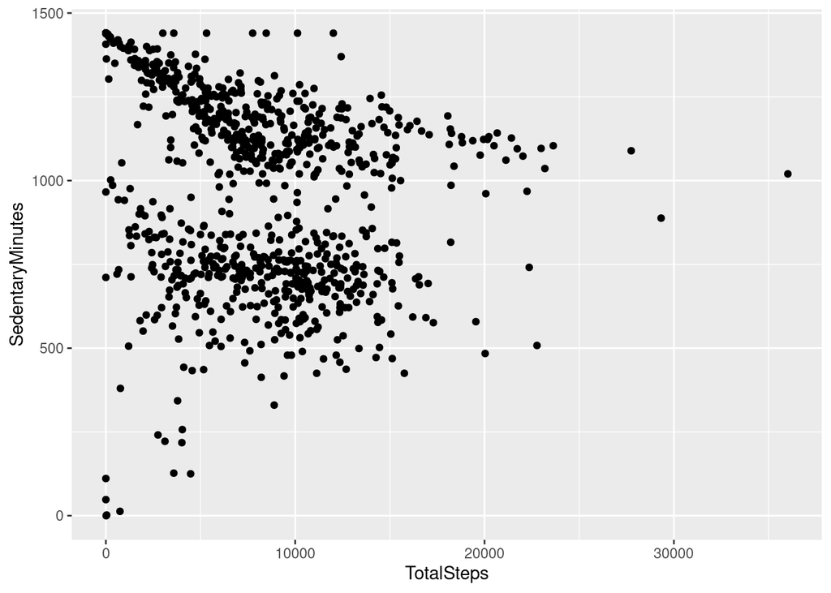

```r
ggplot(data=daily_activity, aes(x=TotalSteps, y=SedentaryMinutes)) + geom_point()
```

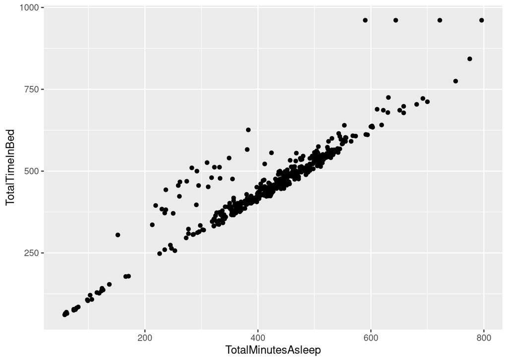

```r
ggplot(data=sleep_day, aes(x=TotalMinutesAsleep, y=TotalTimeInBed)) + geom_point()
```

# With our datasets having id in common we can merge them together

```r
combined_data <- merge(sleep_day, daily_activity, by = "Id")
```

```r
combined_data <- merge(combined_data,weight_Log_Info, by = "Id")
```

# How many participants are in the dataset

```r
install.packages("dplyr")
library(dplyr)

n_distinct(combined_data$Id)
```

```
## [1] 6
```

# Number of unique participants are 6 in the combined_data

```r
length(unique(combined_data$Id))
```

```
## [1] 6
```

# Six participants were merged,and now we want to include the others as well

```r
library(dplyr)

combined_data <- merge(sleep_day, daily_activity, by = "Id", all = TRUE)

combined_data <- merge(combined_data, weight_Log_Info, by = "Id", all = TRUE)
```

# Now let’s check the number of participants again

```r
length(unique(combined_data$Id))
```

```
## [1] 33
```

# Now we have a total number of 33, which correspond to the highest number of participants (Id) which is the daily_activity dataset.

# Load necessary libraries

# Visualizing Relationships: ggplot2 is used to create scatter plots with linear regression lines to visualize relationships between various daily_activity and sleep_day metrics.

## Plot relationship between total steps and total minutes asleep

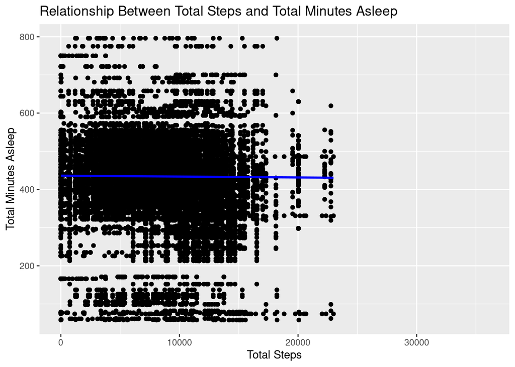

```r
ggplot(combined_data, aes(x = TotalSteps, y = TotalMinutesAsleep)) +
  geom_point() +
  geom_smooth(method = "lm", col = "blue") +
  labs(title = "Relationship Between Total Steps and Total Minutes Asleep", x = "Total Steps", y = "Total Minutes Asleep")
```

## X-Axis (Total Steps): Represents the total number of steps taken by a participant in a day.Y-Axis (Total Minutes Asleep): Represents the total number of minutes a participant was asleep in a day. *Scatter Points: Each point represents a participant’s data for a particular day.* Linear Regression Line (blue line): Shows the general trend or relationship between the total steps and the total minutes asleep. The slope of the line indicates whether there is a positive or negative relationship. *Horizontal Line: Indicates that the number of steps a participant takes does not have any noticeable effect on the total minutes they sleep. Regardless of whether a participant takes few or many steps, their sleep duration remains roughly the same.

# Plot relationship between total distance and total sleep records

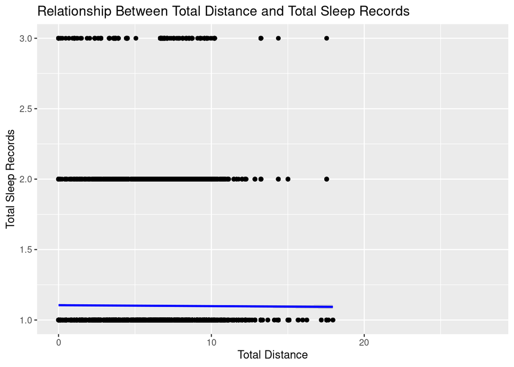

```r
ggplot(combined_data, aes(x = TotalDistance, y = TotalSleepRecords)) +
  geom_point() +
  geom_smooth(method = "lm", col = "blue") +
  labs(title = "Relationship Between Total Distance and Total Sleep Records", x = "Total Distance", y = "Total Sleep Records")
```

Horizontal Line: Suggests that the total distance covered by a participant does not significantly affect the number of sleep records. Whether a participant covers a short or long distance, the number of times sleep is recorded remains consistent.

# Plot relationship between very active minutes and total time in bed

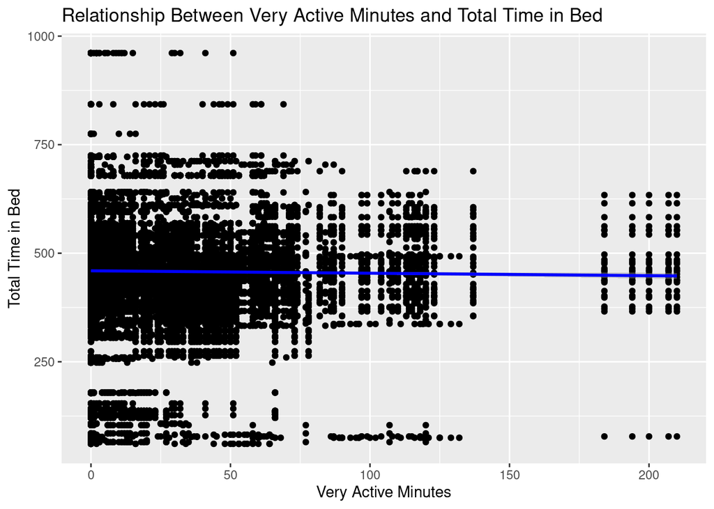

```r
ggplot(combined_data, aes(x = VeryActiveMinutes, y = TotalTimeInBed)) +
  geom_point() +
  geom_smooth(method = "lm", col = "blue") +
  labs(title = "Relationship Between Very Active Minutes and Total Time in Bed", x = "Very Active Minutes", y = "Total Time in Bed")
```

Horizontal Line: Indicates that the amount of time spent being very active does not have a significant impact on the total time a participant spends in bed. Whether a participant is very active for a short or long duration, the total time in bed does not change noticeably.

# Selecting relevant numeric columns from the combined data

```r
numeric_cols <- combined_data %>%
  select(TotalSteps, TotalDistance, VeryActiveMinutes, TotalMinutesAsleep, TotalSleepRecords, TotalTimeInBed)
```

# Calculate correlation matrix

```r
correlation_matrix <- cor(numeric_cols, use = "complete.obs")
```

# Now let’s check relationships and trends with activity and weight

```r
numeric_cols <- combined_data %>% select_if(is.numeric)
```

# Calculate correlation matrix

```r
correlation_matrix <- cor(numeric_cols, use = "complete.obs")
```

# Print correlation matrix

```r
print(correlation_matrix)
```

```
##                                   Id TotalSleepRecords TotalMinutesAsleep
## Id                        1.00000000      -0.088252261         0.48249588
## TotalSleepRecords        -0.08825226       1.000000000        -0.05102292
## TotalMinutesAsleep        0.48249588      -0.051022917         1.00000000
## TotalTimeInBed            0.48663799      -0.040461595         0.99746849
## TotalSteps               -0.60167747       0.053099397        -0.29030690
## TotalDistance            -0.56268790       0.049658480        -0.27149460
## TrackerDistance          -0.56268790       0.049658480        -0.27149460
## LoggedActivitiesDistance          NA                NA                 NA
## VeryActiveDistance       -0.81465690       0.071895313        -0.39306860
## ModeratelyActiveDistance -0.28977376       0.025573189        -0.13981465
## LightActiveDistance      -0.10898814       0.009618449        -0.05258633
## SedentaryActiveDistance           NA                NA                 NA
## VeryActiveMinutes        -0.83196995       0.073423229        -0.40142208
## FairlyActiveMinutes      -0.28754667       0.025376644        -0.13874009
## LightlyActiveMinutes      0.04714275      -0.004160454         0.02274618
## SedentaryMinutes         -0.22153579       0.019551034        -0.10689011
## Calories                  0.27966467      -0.024681039         0.13493705
## WeightKg                  1.00000000      -0.088252261         0.48249588
## WeightPounds              1.00000000      -0.088252261         0.48249588
## Fat                       1.00000000      -0.088252261         0.48249588
## BMI                       1.00000000      -0.088252261         0.48249588
## LogId                    -1.00000000       0.088252261        -0.48249588
##                          TotalTimeInBed  TotalSteps TotalDistance
## Id                           0.48663799 -0.60167747   -0.56268790
## TotalSleepRecords           -0.04046159  0.05309940    0.04965848
## TotalMinutesAsleep           0.99746849 -0.29030690   -0.27149460
## TotalTimeInBed               1.00000000 -0.29279912   -0.27382531
## TotalSteps                  -0.29279912  1.00000000    0.99783328
## TotalDistance               -0.27382531  0.99783328    1.00000000
## TrackerDistance             -0.27382531  0.99783328    1.00000000
## LoggedActivitiesDistance             NA          NA            NA
## VeryActiveDistance          -0.39644299  0.76823770    0.74873613
## ModeratelyActiveDistance    -0.14101492  0.53322394    0.52771371
## LightActiveDistance         -0.05303777  0.68757526    0.70701696
## SedentaryActiveDistance              NA          NA            NA
## VeryActiveMinutes           -0.40486819  0.77114582    0.74675502
## FairlyActiveMinutes         -0.13993114  0.53782468    0.53352019
## LightlyActiveMinutes         0.02294145  0.57616040    0.60084417
## SedentaryMinutes            -0.10780773  0.01720169    0.01194647
```

[output cut: 152 more lines]

```
## LoggedActivitiesDistance          NA
## VeryActiveDistance        0.81465690
## ModeratelyActiveDistance  0.28977376
## LightActiveDistance       0.10898814
## SedentaryActiveDistance           NA
## VeryActiveMinutes         0.83196995
## FairlyActiveMinutes       0.28754667
## LightlyActiveMinutes     -0.04714275
## SedentaryMinutes          0.22153579
## Calories                 -0.27966467
## WeightKg                 -1.00000000
## WeightPounds             -1.00000000
## Fat                      -1.00000000
## BMI                      -1.00000000
## LogId                     1.00000000
```

# Visualize correlation matrix

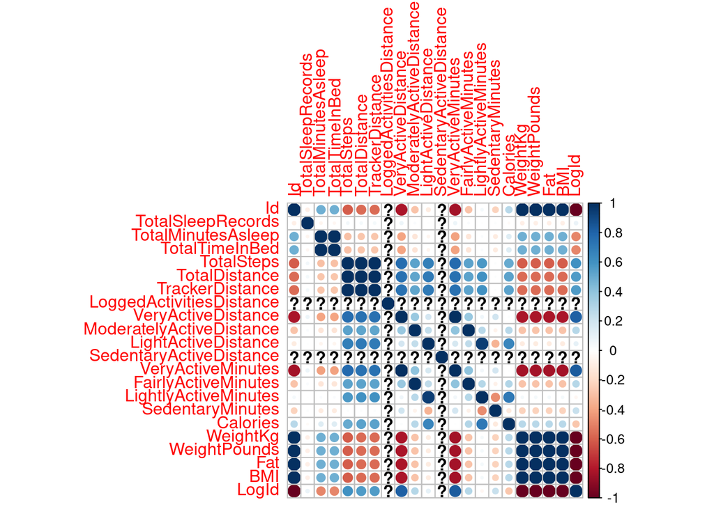

```r
library(corrplot)
corrplot(correlation_matrix, method = "circle")
```

#Create visualizations to identify relationships and trends in Very Active Minutes and Weight Kg.

```r
library(ggplot2)
```

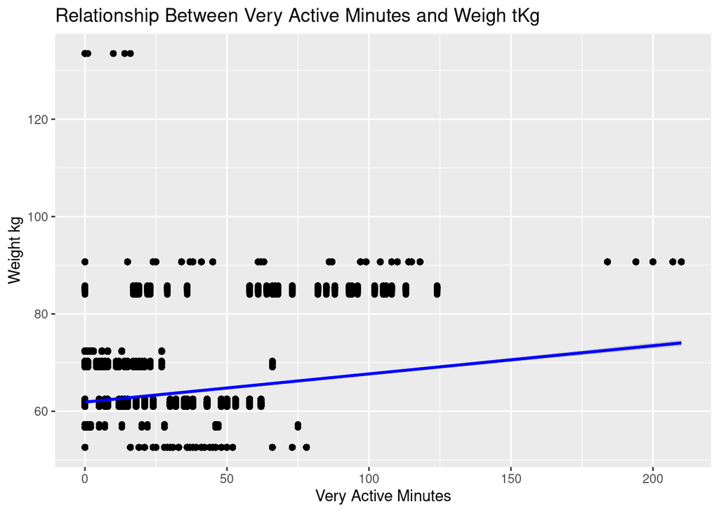

```r
ggplot(combined_data, aes(x = VeryActiveMinutes, y = WeightKg)) +
  geom_point() +
  geom_smooth(method = "lm", col = "blue") +
  labs(title = "Relationship Between Very Active Minutes and Weigh tKg", x = "Very Active Minutes", y = "Weight kg")
```

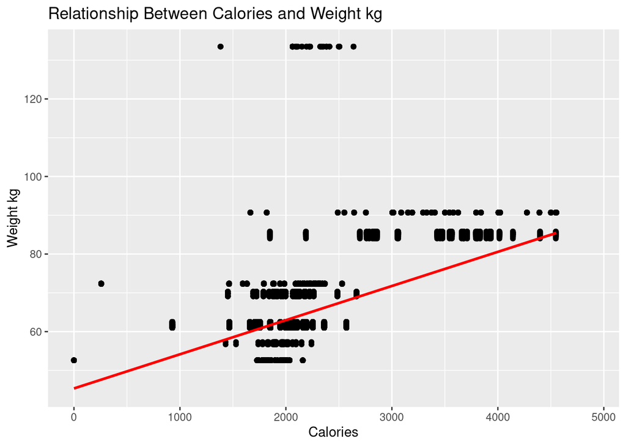

```r
ggplot(combined_data, aes(x = Calories, y = WeightKg)) +
  geom_point() +
  geom_smooth(method = "lm", col = "red") +
  labs(title = "Relationship Between Calories and Weight kg", x = "Calories", y = "Weight kg")
```

# Let’s create a weight category (e.g., Underweight, Normal, Overweight)

```r
combined_data <- combined_data %>%
  mutate(WeightCategory = case_when(
    BMI < 18.5 ~ "Underweight",
    BMI >= 18.5 & BMI < 24.9 ~ "Normal",
    BMI >= 25 & BMI < 29.9 ~ "Overweight",
    BMI >= 30 ~ "Obese"
  ))
```

# The box plot categorizes weight and compares the distribution of activity minutes across these categories.

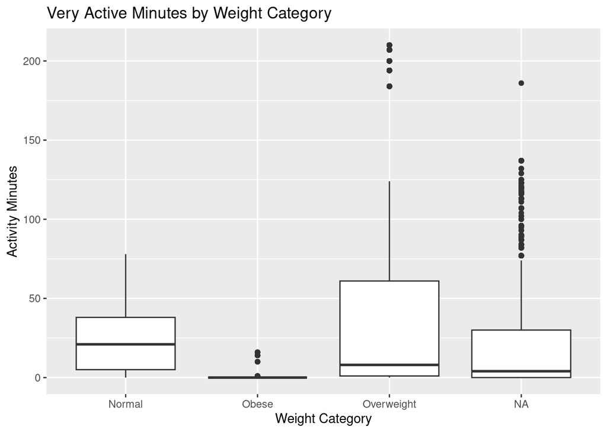

```r
ggplot(combined_data, aes(x = WeightCategory, y = VeryActiveMinutes)) +
  geom_boxplot() +
  labs(title = "Very Active Minutes by Weight Category", x = "Weight Category", y = "Activity Minutes")
```

# Summary statistics for Activity and Weight

```r
summary_stats <- combined_data %>%
  summarise(
    total_ids = n_distinct(Id),
    mean_activity = mean(VeryActiveMinutes, na.rm = TRUE),
    mean_weight = mean(WeightKg, na.rm = TRUE),
    sd_activity = sd(VeryActiveMinutes, na.rm = TRUE),
    sd_weight = sd(WeightKg, na.rm = TRUE)
  )

print(summary_stats)
```

```
##   total_ids mean_activity mean_weight sd_activity sd_weight
## 1        33      23.58562     63.3196    26.07449  7.875164
```

## Observation

- Mean - The average amount of activity per day is approximately 23.59 minutes. This suggests that, on average, participants are engaging in relatively low levels of physical activity each day. Depending on the context this could be considered insufficient.
- The standard deviation of 26.07 minutes is quite high relative to the mean. This indicates a wide variation in the amount of daily activity among participants. Some participants are likely engaging in much higher levels of physical activity, while others may be engaging in very little or none.
- The fact that the standard deviation is greater than the mean suggests that the distribution of activity minutes is highly variable. This could imply that the dataset includes a mix of very active and very inactive participants, rather than a more uniform distribution of activity levels.

## Interpretation

- The high standard deviation indicates that while the average activity is low, there are participants with significantly higher and lower activity levels. This wide range can be seen as a positive sign if it includes very active individuals, but it also highlights a substantial portion of the population that may not be engaging in sufficient physical activity.
- Given the high standard deviation, there may be outliers in the data, such as participants with exceptionally high or low activity minutes. It would be useful to examine a histogram or box plot of the activity data to visualize this distribution and identify any outliers.
- If the data represents a broader population, the low average activity level could indicate a need for public health interventions aimed at increasing daily physical activity. This might include programs to encourage more frequent exercise or promote active lifestyles.

## Recommendations

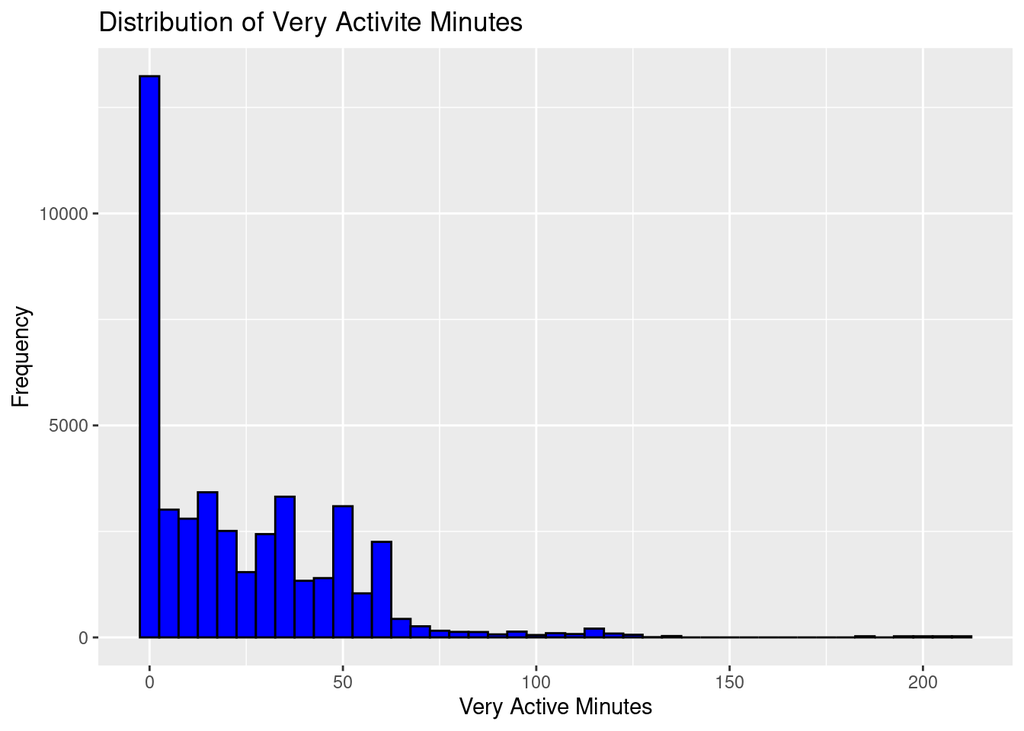

```r
ggplot(combined_data, aes(x = VeryActiveMinutes)) +
  geom_histogram(binwidth = 5, fill = "blue", color = "black") +
  labs(title = "Distribution of Very Activite Minutes", x = "Very Active Minutes", y = "Frequency")
```

## Observations: * The distribution is heavily right-skewed, with a large number of participants recording very few “Very Active Minutes” each day. There is a significant peak at 0 “Very Active Minutes,” indicating that many participants did not engage in any very active minutes on many days.The frequency of participants with very active minutes decreases as the number of active minutes increases. * The tail extends to the right, showing that a smaller number of participants engage in higher levels of very active minutes. There is a rapid decline in frequency as very active minutes increase. Most participants have fewer than 50 very active minutes per day. There are a few participants with very high active minutes (over 100, and even up to 200+). These outliers represent individuals with exceptionally high levels of very active minutes.

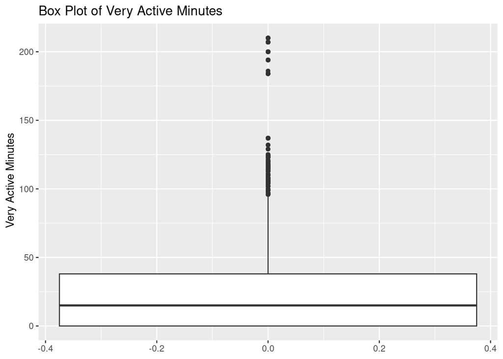

```r
ggplot(combined_data, aes(y = VeryActiveMinutes)) +
  geom_boxplot() +
  labs(title = "Box Plot of Very Active Minutes", y = " Very Active Minutes")
```

*The box itself represents the interquartile range (IQR), which is the range between the first quartile (25th percentile) and the third quartile (75th percentile). The IQR is relatively small, suggesting that the majority of participants have low levels of very active minutes.

## Explanations:

- The low median and small IQR indicate that most participants engage in few or no very active minutes. This aligns with the histogram’s observation of a right-skewed distribution with a high frequency of low activity levels.
- The numerous outliers suggest a high degree of variability in the dataset. While most participants are not very active, there is a notable subset that is highly active, which significantly skews the data. The presence of these outliers contributes to the high standard deviation observed in the summary statistics.
- The data suggests a need for initiatives to increase very active minutes among the majority of participants. Programs encouraging moderate to vigorous physical activity could help in achieving better health outcomes.
- The outliers might represent specific groups, such as athletes or individuals with highly active lifestyles. Understanding the characteristics of these outliers could help in designing targeted interventions.

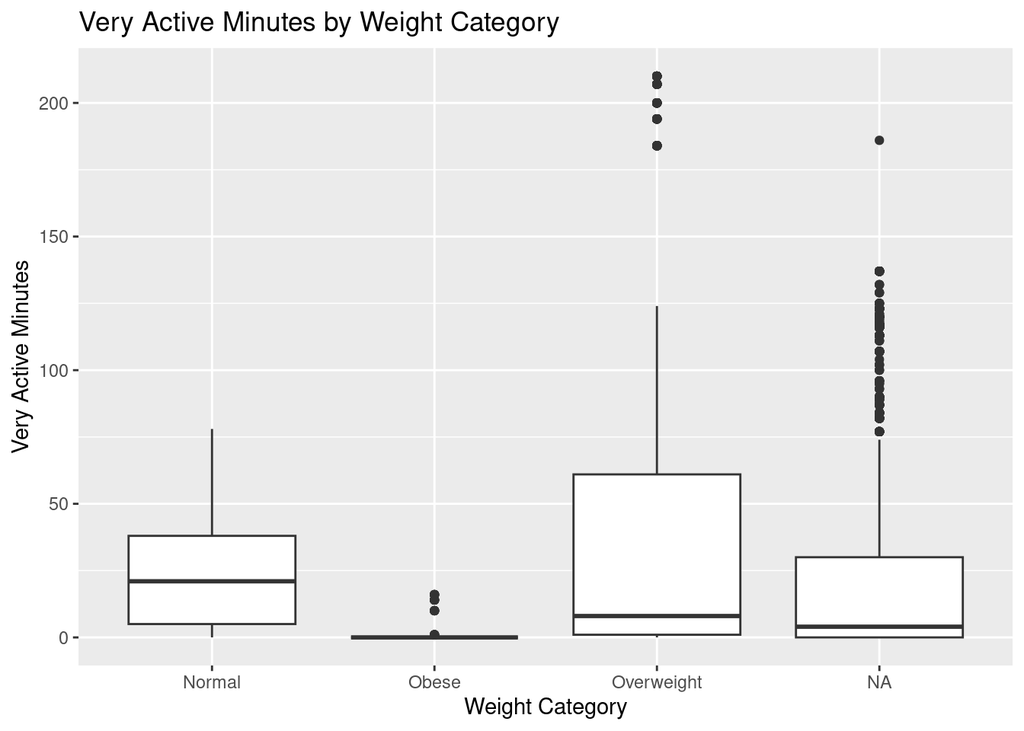

```r
ggplot(combined_data, aes(x = WeightCategory, y = VeryActiveMinutes)) +
  geom_boxplot() +
  labs(title = "Very Active Minutes by Weight Category", x = "Weight Category", y = "Very Active Minutes")
```

```r
combined_data %>%
  filter( VeryActiveMinutes > (mean(VeryActiveMinutes, na.rm = TRUE) + 3 * sd(VeryActiveMinutes, na.rm = TRUE)) |
         VeryActiveMinutes < (mean(VeryActiveMinutes, na.rm = TRUE) - 3 * sd(VeryActiveMinutes, na.rm = TRUE))) %>%
  select(Id, VeryActiveMinutes)
```

```
##             Id VeryActiveMinutes
## 1   1624580081               186
## 2   2022484408               104
## 3   4388161847               120
## 4   4388161847               107
## 5   4388161847               120
## 6   4388161847               107
## 7   4388161847               120
## 8   4388161847               107
## 9   4388161847               120
## 10  4388161847               107
## 11  4388161847               120
## 12  4388161847               107
## 13  4388161847               120
## 14  4388161847               107
```

[output cut: 720 more lines]

## What are some trends in smart device usage?How could these trends apply to Bellabeat customers?How could these trends help influence Bellabeat marketing strategy?

- Understanding Consumer Behavior: The analysis of daily activity and weight data helps in understanding how Bellabeat’s target audience (women using smart devices) are engaging with their health and wellness. This understanding can inform the marketing strategy by highlighting the typical activity levels and weight profiles of users, and identifying patterns or outliers.
- Product Features and Benefits: Insights into how physical activity correlates with weight can be used to emphasize the benefits of Bellabeat’s products. For example, if the data shows that higher activity levels are associated with healthier weight profiles, marketing can highlight how Bellabeat products help users track and increase their daily activity to achieve better health outcomes.
- Targeted Marketing Campaigns: The variability in activity levels and the potential identification of different user segments (e.g., highly active vs. less active users) can lead to more targeted marketing campaigns. Personalized messages can be crafted to address the specific needs and goals of different user groups.

## High-Level Recommendations for Marketing Strategy:

*Emphasize Personalization: Data Insight: The wide range of activity levels and the mean activity being relatively low suggest that users have diverse activity habits and needs.

*Recommendation: Highlight the personalized tracking and tailored recommendations features of Bellabeat products in marketing materials. Promote how the devices can adapt to each user’s lifestyle and help them achieve their personal health goals.

## Promote Health and Wellness Benefits:

*Recommendation: Use testimonials, case studies, and data-driven content to show how increased activity tracked by Bellabeat devices has led to positive health outcomes. Create campaigns around success stories of users who have improved their health metrics using Bellabeat products.

##Segmented Marketing Campaigns: * Data Insight: The variability in activity levels indicates different segments of users.

*Recommendation: Develop marketing strategies tailored to different user segments identified through data analysis. For example, create distinct campaigns for new mothers, fitness enthusiasts, and women looking to manage stress. Each campaign can focus on the specific benefits relevant to these groups, such as sleep tracking for new mothers or stress management features for busy professionals.

## Educational Content:

- Data Insight: The standard deviation indicates a wide variation in user engagement.
- Recommendation: Invest in educational content that helps users understand the importance of regular physical activity and how Bellabeat devices can help them track and improve their activity levels. This content can be distributed through blogs, social media, webinars, and email newsletters.

## Leveraging Digital Marketing Channels:

- Data Insight: Bellabeat already uses a variety of digital marketing channels.
- Recommendation: Use insights from the data to create more engaging and informative content for social media, Google Search, YouTube, and display ads. Highlight data-driven results and benefits of using Bellabeat products to attract new customers and retain existing ones.

*Example Campaign Ideas: “30-Day Activity Challenge”: Encourage users to increase their daily activity with a challenge. Use data to show typical activity levels and set achievable goals. “Real Stories, Real Results”: Share real user stories and data showing the impact of Bellabeat products on their health. “Know Your Numbers”: An educational campaign explaining the importance of tracking health metrics and how Bellabeat products can help.